# Lab 7 part 2

2022-11-02

```r
library(ggplot2)
```

First we read and explore the data

```r
df <- read.csv("data-independent-practice/titanic-analysis.csv",stringsAsFactors = T)
head(df)
```

```
##   PassengerId Survived    Sex Age    Fare
## 1           1        0   male  22  7.2500
## 2           2        1 female  38 71.2833
## 3           3        1 female  26  7.9250
## 4           4        1 female  35 53.1000
## 5           5        0   male  35  8.0500
## 6           6        0   male  NA  8.4583
```

The survival should be a factor, as it is binary:

```r
df$Survived <- as.factor(df$Survived)
```

We can check for NA:

```r
which(is.na(df$Survived))
```

```
## integer(0)
```

```r
which(is.na(df$Sex))
```

```
## integer(0)
```

```r
which(is.na(df$Age))
```

```
##   [1]   6  18  20  27  29  30  32  33  37  43  46  47  48  49  56  65  66  77
##  [19]  78  83  88  96 102 108 110 122 127 129 141 155 159 160 167 169 177 181
##  [37] 182 186 187 197 199 202 215 224 230 236 241 242 251 257 261 265 271 275
##  [55] 278 285 296 299 301 302 304 305 307 325 331 335 336 348 352 355 359 360
##  [73] 365 368 369 376 385 389 410 411 412 414 416 421 426 429 432 445 452 455
##  [91] 458 460 465 467 469 471 476 482 486 491 496 498 503 508 512 518 523 525
## [109] 528 532 534 539 548 553 558 561 564 565 569 574 579 585 590 594 597 599
## [127] 602 603 612 613 614 630 634 640 644 649 651 654 657 668 670 675 681 693
## [145] 698 710 712 719 728 733 739 740 741 761 767 769 774 777 779 784 791 793
## [163] 794 816 826 827 829 833 838 840 847 850 860 864 869 879 889
```

```r
which(is.na(df$Fare))
```

```
## integer(0)
```

We can see there is a bast amount of NA for Age. In this case, we will not do anything and proceed, as it does not affect too much our study.

```r
summary(df)
```

```
##   PassengerId    Survived     Sex           Age             Fare
##  Min.   :  1.0   0:549    female:314   Min.   : 0.42   Min.   :  0.00
##  1st Qu.:223.5   1:342    male  :577   1st Qu.:20.12   1st Qu.:  7.91
##  Median :446.0                         Median :28.00   Median : 14.45
##  Mean   :446.0                         Mean   :29.70   Mean   : 32.20
##  3rd Qu.:668.5                         3rd Qu.:38.00   3rd Qu.: 31.00
##  Max.   :891.0                         Max.   :80.00   Max.   :512.33
##                                        NA's   :177
```

We can see that the minimum age is 0.42. We suppose it wanted to mean 42, so we change it:

```r
which.min(df$Age)
```

```
## [1] 804
```

```r
df$Age[804] <- 42
```

```r
df$Age <- as.integer(df$Age)
```

```r
summary(df)
```

```
##   PassengerId    Survived     Sex           Age             Fare
##  Min.   :  1.0   0:549    female:314   Min.   : 0.00   Min.   :  0.00
##  1st Qu.:223.5   1:342    male  :577   1st Qu.:20.25   1st Qu.:  7.91
##  Median :446.0                         Median :28.00   Median : 14.45
##  Mean   :446.0                         Mean   :29.74   Mean   : 32.20
##  3rd Qu.:668.5                         3rd Qu.:38.00   3rd Qu.: 31.00
##  Max.   :891.0                         Max.   :80.00   Max.   :512.33
##                                        NA's   :177
```

Error spotted, age cannot be 0 (Might not be an error, might just be babies so we will not take further action and consider them as babies)

```r
which(df$Age == 0)
```

```
## [1]  79 306 470 645 756 832
```

```r
table(df$Survived)
```

```
##
##   0   1
## 549 342
```

We can now check the relation between the sex and the survival:

```r
table(df$Survived, df$Sex)
```

```
##
##     female male
##   0     81  468
##   1    233  109
```

As seen, males had much less chances of surviving than females.

Exploring the relationship between the target variable and the numerical explanatory variables:

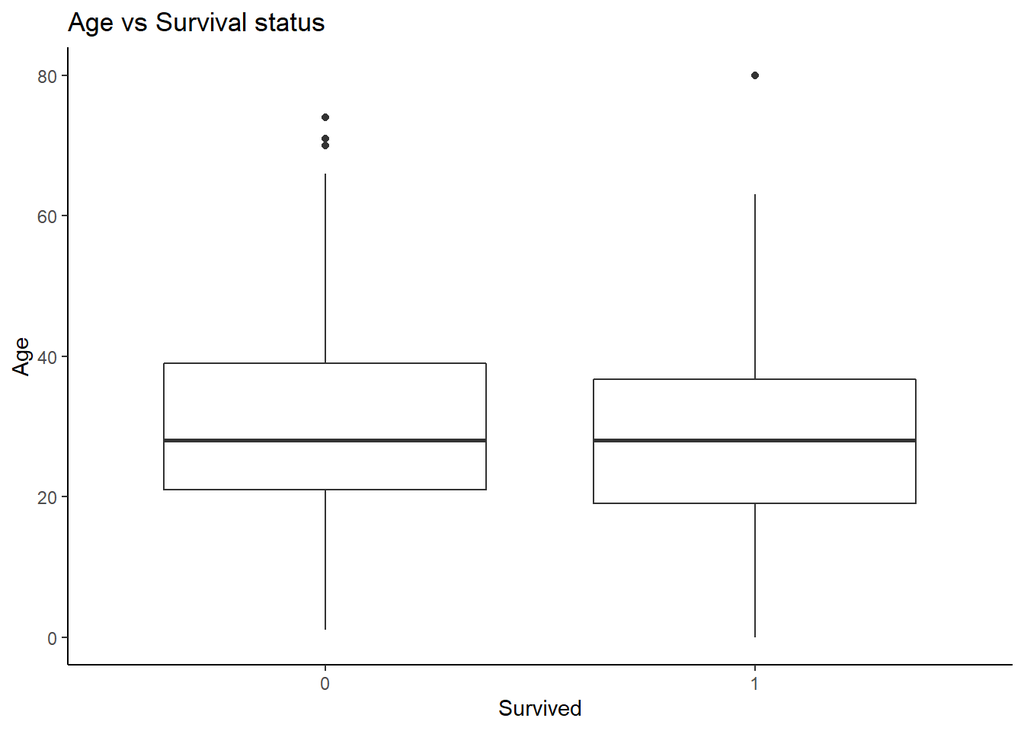

```r
ggplot(df, aes(x=Survived, y=Age))+ geom_boxplot() + theme_classic()+ ggtitle("Age vs Survival status")
```

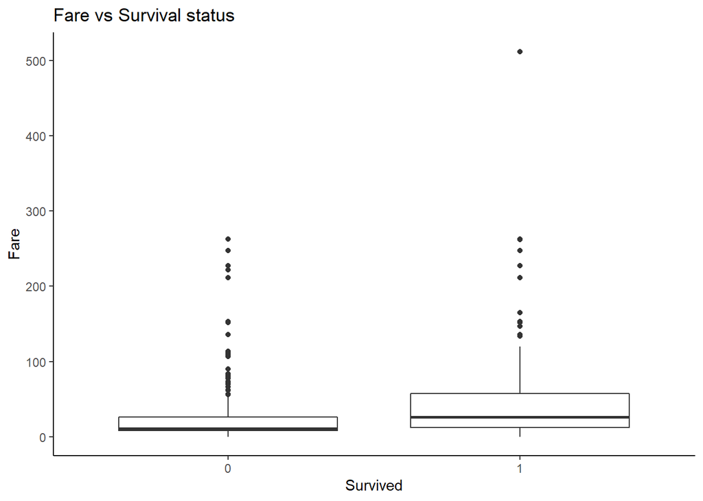

```r
ggplot(df, aes(x=Survived, y=Fare))+ geom_boxplot() + theme_classic() + ggtitle("Fare vs Survival status")
```

We can clearly see that age did not have an impact on whether you would survive or not. On the other hand, people who survived generally paid higher fares, maybe for better seats or seats with better assistance?

Lets start with this maximal model without interactions just to focus on the process and interpreting the outputs.

```r
df.lr<-glm(df$Survived~df$Sex+ df$Age+df$Fare, family=binomial)
summary(df.lr)
```

```
##
## Call:
## glm(formula = df$Survived ~ df$Sex + df$Age + df$Fare, family = binomial)
##
## Deviance Residuals:
##     Min       1Q   Median       3Q      Max
## -2.3919  -0.6355  -0.5906   0.7911   2.0138
##
## Coefficients:
##              Estimate Std. Error z value Pr(>|z|)
## (Intercept)  0.898548   0.238486   3.768 0.000165 ***
## df$Sexmale  -2.349622   0.190021 -12.365  < 2e-16 ***
## df$Age      -0.009171   0.006489  -1.413 0.157554
## df$Fare      0.012679   0.002688   4.717 2.39e-06 ***
## ---
## Signif. codes:  0 '***' 0.001 '**' 0.01 '*' 0.05 '.' 0.1 ' ' 1
##
## (Dispersion parameter for binomial family taken to be 1)
##
##     Null deviance: 964.52  on 713  degrees of freedom
## Residual deviance: 716.73  on 710  degrees of freedom
##   (177 observations deleted due to missingness)
## AIC: 724.73
##
## Number of Fisher Scoring iterations: 5
```

We can see that the Sex and the Fare are highly significant determining the survival rate.

And we can interpret the model as follows:

For Gender = Male:
$$log(\frac{p}{1-p})=0.898-2.349 \times 1- 0.009
\times \text{age} +0.012 \times \text{fare}$$
Now, we can check the odds ratio:

```r
exp(coef(df.lr))
```

```
## (Intercept)  df$Sexmale      df$Age     df$Fare
##  2.45603386  0.09540521  0.99087077  1.01275982
```

The odds of survival for gender=male are 0.095 - in other words they decrease by a factor 0.095. Therefore, males had a strongly smaller chance of survival.

For a one unit increase in age, the odds of survival increase by a factor of 0.99 - in other words they decrease by a very slightly small amount.

Lastly, for a one unit increase in fare price, the odds of survival increase by a factor of 1.012 - in other words they increase by a very slightly small amount.

We can summarise that fare price slightly increases survival likelihood marginally. Gender = male decrease the likelihood.

Now, we can start over with the bigger dataset and then compare accuracy with the predictions:

```r
df2 <- read.csv("data-independent-practice/titanic-all-cols.csv",stringsAsFactors = T)
head(df2)
```

```
##   PassengerId Survived Pclass
## 1           1        0      3
## 2           2        1      1
## 3           3        1      3
## 4           4        1      1
## 5           5        0      3
## 6           6        0      3
##                                                  Name    Sex Age SibSp Parch
## 1                             Braund, Mr. Owen Harris   male  22     1     0
## 2 Cumings, Mrs. John Bradley (Florence Briggs Thayer) female  38     1     0
## 3                              Heikkinen, Miss. Laina female  26     0     0
## 4        Futrelle, Mrs. Jacques Heath (Lily May Peel) female  35     1     0
## 5                            Allen, Mr. William Henry   male  35     0     0
## 6                                    Moran, Mr. James   male  NA     0     0
##             Ticket    Fare Cabin Embarked
## 1        A/5 21171  7.2500              S
## 2         PC 17599 71.2833   C85        C
## 3 STON/O2. 3101282  7.9250              S
## 4           113803 53.1000  C123        S
## 5           373450  8.0500              S
## 6           330877  8.4583              Q
```

```r
df2$Survived <- as.factor(df2$Survived)
df2$Pclass <- as.factor(df2$Pclass)
#df2$SibSp <- as.factor(df2$SibSp)
#df2$Parch <- as.factor(df2$Parch)
```

We can check the data again

```r
View(df2)
```

```r
summary(df2)
```

```
##   PassengerId    Survived Pclass                                     Name
##  Min.   :  1.0   0:549    1:216   Abbing, Mr. Anthony                  :  1
##  1st Qu.:223.5   1:342    2:184   Abbott, Mr. Rossmore Edward          :  1
##  Median :446.0            3:491   Abbott, Mrs. Stanton (Rosa Hunt)     :  1
##  Mean   :446.0                    Abelson, Mr. Samuel                  :  1
##  3rd Qu.:668.5                    Abelson, Mrs. Samuel (Hannah Wizosky):  1
##  Max.   :891.0                    Adahl, Mr. Mauritz Nils Martin       :  1
##                                   (Other)                              :885
##      Sex           Age            SibSp           Parch             Ticket
##  female:314   Min.   : 0.42   Min.   :0.000   Min.   :0.0000   1601    :  7
##  male  :577   1st Qu.:20.12   1st Qu.:0.000   1st Qu.:0.0000   347082  :  7
##               Median :28.00   Median :0.000   Median :0.0000   CA. 2343:  7
##               Mean   :29.70   Mean   :0.523   Mean   :0.3816   3101295 :  6
##               3rd Qu.:38.00   3rd Qu.:1.000   3rd Qu.:0.0000   347088  :  6
##               Max.   :80.00   Max.   :8.000   Max.   :6.0000   CA 2144 :  6
##               NA's   :177                                      (Other) :852
##       Fare                Cabin     Embarked
##  Min.   :  0.00              :687    :  2
##  1st Qu.:  7.91   B96 B98    :  4   C:168
##  Median : 14.45   C23 C25 C27:  4   Q: 77
##  Mean   : 32.20   G6         :  4   S:644
##  3rd Qu.: 31.00   C22 C26    :  3
##  Max.   :512.33   D          :  3
##                   (Other)    :186
```

Fix the things that are off

```r
df2$Age[804] <- 42
df2$Embarked[df2$Embarked == ""] <- NA
```

```r
summary(df2)
```

```
##   PassengerId    Survived Pclass                                     Name
##  Min.   :  1.0   0:549    1:216   Abbing, Mr. Anthony                  :  1
##  1st Qu.:223.5   1:342    2:184   Abbott, Mr. Rossmore Edward          :  1
##  Median :446.0            3:491   Abbott, Mrs. Stanton (Rosa Hunt)     :  1
##  Mean   :446.0                    Abelson, Mr. Samuel                  :  1
##  3rd Qu.:668.5                    Abelson, Mrs. Samuel (Hannah Wizosky):  1
##  Max.   :891.0                    Adahl, Mr. Mauritz Nils Martin       :  1
##                                   (Other)                              :885
##      Sex           Age            SibSp           Parch             Ticket
##  female:314   Min.   : 0.67   Min.   :0.000   Min.   :0.0000   1601    :  7
##  male  :577   1st Qu.:20.62   1st Qu.:0.000   1st Qu.:0.0000   347082  :  7
##               Median :28.00   Median :0.000   Median :0.0000   CA. 2343:  7
##               Mean   :29.76   Mean   :0.523   Mean   :0.3816   3101295 :  6
##               3rd Qu.:38.00   3rd Qu.:1.000   3rd Qu.:0.0000   347088  :  6
##               Max.   :80.00   Max.   :8.000   Max.   :6.0000   CA 2144 :  6
##               NA's   :177                                      (Other) :852
##       Fare                Cabin     Embarked
##  Min.   :  0.00              :687       :  0
##  1st Qu.:  7.91   B96 B98    :  4   C   :168
##  Median : 14.45   C23 C25 C27:  4   Q   : 77
##  Mean   : 32.20   G6         :  4   S   :644
##  3rd Qu.: 31.00   C22 C26    :  3   NA's:  2
##  Max.   :512.33   D          :  3
##                   (Other)    :186
```

Also, to simplify things, we are going to make the cabin binary: 0 for not having a cabin and 1 for having one

```r
df2$Cabin <- as.character(df2$Cabin)
df2$Cabin[df2$Cabin == ""] <- 0
```

```r
df2$Cabin[df2$Cabin != 0] <- 1
df2$Cabin <- as.factor(df2$Cabin)
```

Exploring the dataset, it looks like GENERALLY, the cabins correspond to more expensive fares (which was guessed previously).

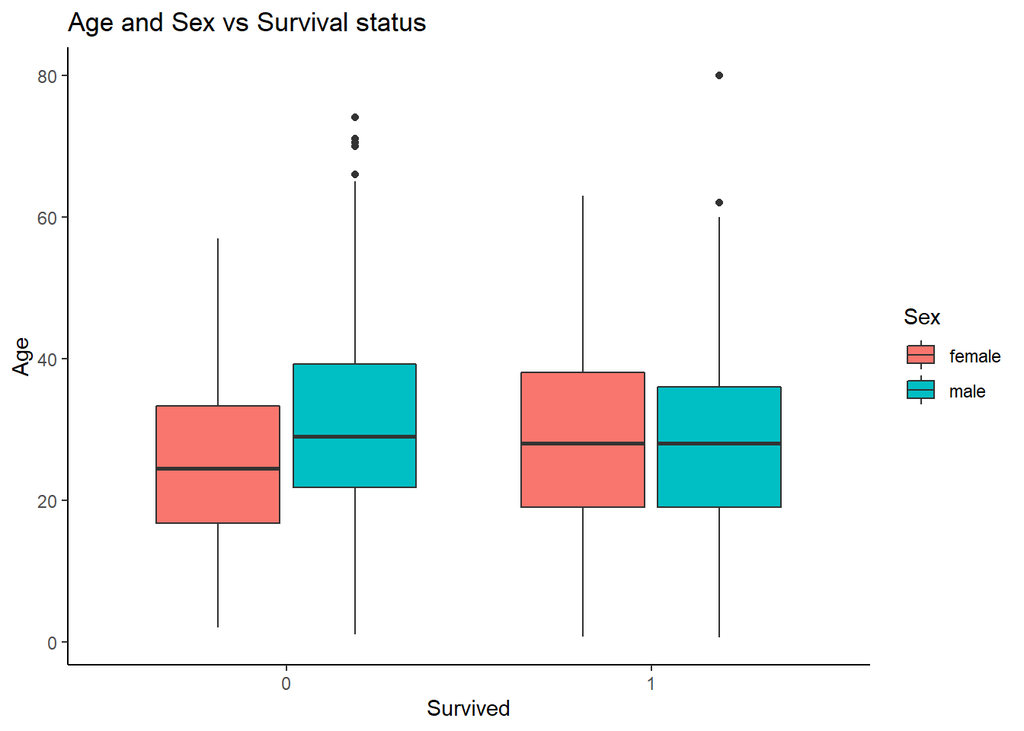

```r
ggplot(df2, aes(x=Survived, y=Age, fill = Sex))+ geom_boxplot() + theme_classic()+ ggtitle("Age and Sex vs Survival status")
```

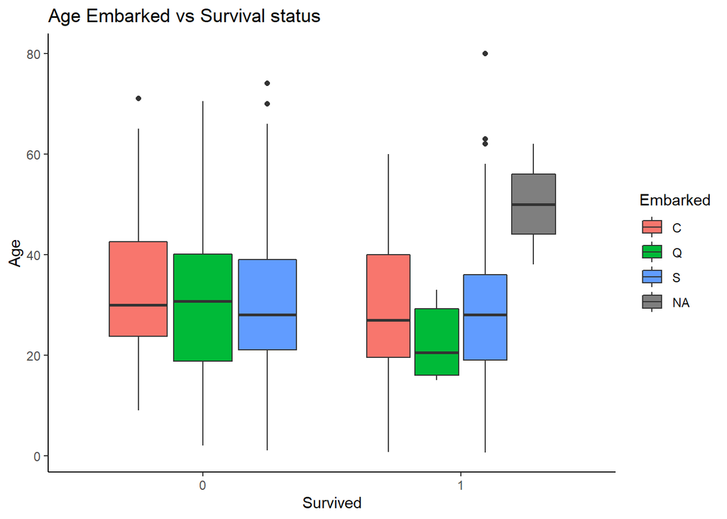

```r
ggplot(df2, aes(x=Survived, y=Age, fill = Embarked))+ geom_boxplot() + theme_classic()+ ggtitle("Age Embarked vs Survival status")
```

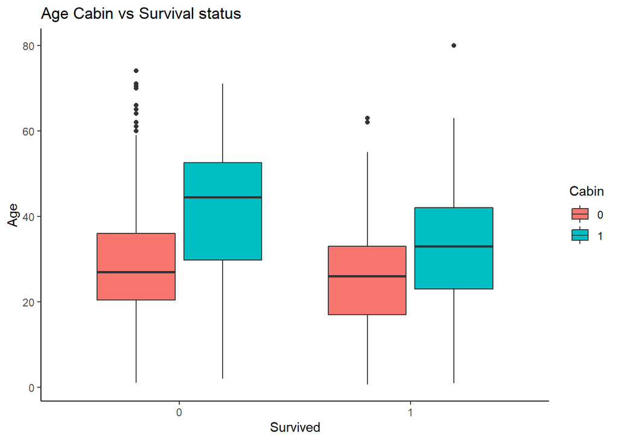

```r
ggplot(df2, aes(x=Survived, y=Age, fill = Cabin))+ geom_boxplot() + theme_classic()+ ggtitle("Age Cabin vs Survival status")
```

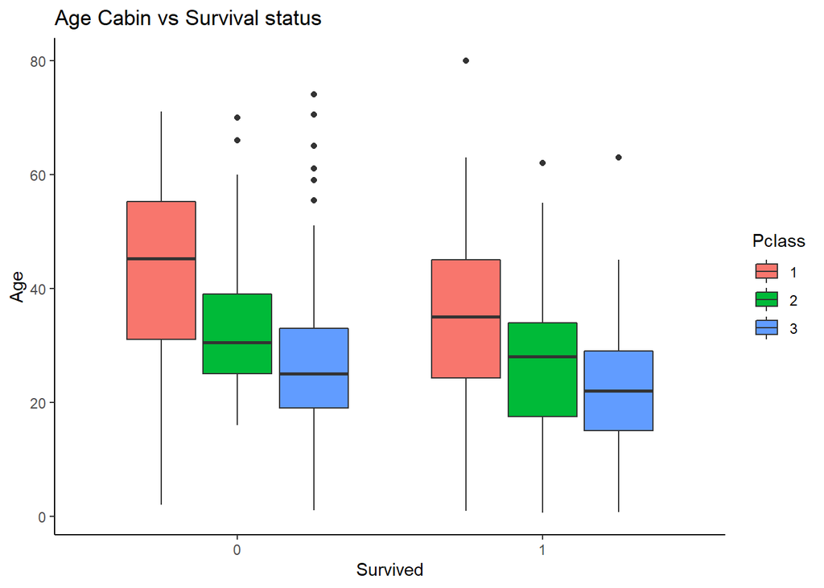

```r
ggplot(df2, aes(x=Survived, y=Age, fill = Pclass))+ geom_boxplot() + theme_classic()+ ggtitle("Age Cabin vs Survival status")
```

Lets run a maximal model without interactions:

```r
df2.max.lr<-glm(df$Survived~df2$Pclass+df2$Sex+df2$Age+df2$SibSp+df2$Parch+df2$Fare+df2$Cabin+df2$Embarked, family=binomial)
summary(df2.max.lr)
```

```
##
## Call:
## glm(formula = df$Survived ~ df2$Pclass + df2$Sex + df2$Age +
##     df2$SibSp + df2$Parch + df2$Fare + df2$Cabin + df2$Embarked,
##     family = binomial)
##
## Deviance Residuals:
##     Min       1Q   Median       3Q      Max
## -2.6985  -0.6364  -0.3823   0.6171   2.4267
##
## Coefficients:
##                Estimate Std. Error z value Pr(>|z|)
## (Intercept)    3.694070   0.624012   5.920 3.22e-09 ***
## df2$Pclass2   -0.582781   0.442583  -1.317 0.187915
## df2$Pclass3   -1.732221   0.463188  -3.740 0.000184 ***
## df2$Sexmale   -2.615730   0.222940 -11.733  < 2e-16 ***
## df2$Age       -0.040049   0.008311  -4.819 1.45e-06 ***
## df2$SibSp     -0.345748   0.129540  -2.669 0.007607 **
## df2$Parch     -0.070246   0.123900  -0.567 0.570744
## df2$Fare       0.001305   0.002572   0.508 0.611789
## df2$Cabin1     0.733514   0.376168   1.950 0.051180 .
## df2$EmbarkedQ -0.835934   0.597191  -1.400 0.161581
## df2$EmbarkedS -0.444804   0.274630  -1.620 0.105308
## ---
## Signif. codes:  0 '***' 0.001 '**' 0.01 '*' 0.05 '.' 0.1 ' ' 1
##
## (Dispersion parameter for binomial family taken to be 1)
##
##     Null deviance: 960.90  on 711  degrees of freedom
## Residual deviance: 631.32  on 701  degrees of freedom
##   (179 observations deleted due to missingness)
## AIC: 653.32
##
## Number of Fisher Scoring iterations: 5
```

As seen, Pclass, Sex and Age are highly relevant, and SibSp is relevant.

```r
exp(coef(df2.max.lr))
```

```
##   (Intercept)   df2$Pclass2   df2$Pclass3   df2$Sexmale       df2$Age
##   40.20817637    0.55834360    0.17689106    0.07311437    0.96074206
##     df2$SibSp     df2$Parch      df2$Fare    df2$Cabin1 df2$EmbarkedQ
##    0.70769115    0.93216438    1.00130613    2.08238529    0.43346949
## df2$EmbarkedS
##    0.64094962
```

Interesting to look at.

Now, we are going to use all these data to make predictions of survival, and compare the accuracy of model 1 and model 2:

```r
df$psurvive<-predict(df.lr, newdata = df, type="response")
head(df)
```

```
##   PassengerId Survived    Sex Age    Fare  psurvive
## 1           1        0   male  22  7.2500 0.1735152
## 2           2        1 female  38 71.2833 0.8105906
## 3           3        1 female  26  7.9250 0.6814795
## 4           4        1 female  35 53.1000 0.7774414
## 5           5        0   male  35  8.0500 0.1584244
## 6           6        0   male  NA  8.4583        NA
```

```r
df$prediction[df$psurvive > 0.5 & df$Survived ==1] <- 1
df$prediction[df$psurvive < 0.5 & df$Survived ==1] <- 0
df$prediction[df$psurvive < 0.5 & df$Survived ==0] <- 1
df$prediction[df$psurvive > 0.5 & df$Survived ==0] <- 0
```

```r
head(df)
```

```
##   PassengerId Survived    Sex Age    Fare  psurvive prediction
## 1           1        0   male  22  7.2500 0.1735152          1
## 2           2        1 female  38 71.2833 0.8105906          1
## 3           3        1 female  26  7.9250 0.6814795          1
## 4           4        1 female  35 53.1000 0.7774414          1
## 5           5        0   male  35  8.0500 0.1584244          1
## 6           6        0   male  NA  8.4583        NA         NA
```

```r
df2$psurvive<-predict(df2.max.lr, newdata = df2, type="response")
head(df2)
```

```
##   PassengerId Survived Pclass
## 1           1        0      3
## 2           2        1      1
## 3           3        1      3
## 4           4        1      1
## 5           5        0      3
## 6           6        0      3
##                                                  Name    Sex Age SibSp Parch
## 1                             Braund, Mr. Owen Harris   male  22     1     0
## 2 Cumings, Mrs. John Bradley (Florence Briggs Thayer) female  38     1     0
## 3                              Heikkinen, Miss. Laina female  26     0     0
## 4        Futrelle, Mrs. Jacques Heath (Lily May Peel) female  35     1     0
## 5                            Allen, Mr. William Henry   male  35     0     0
## 6                                    Moran, Mr. James   male  NA     0     0
##             Ticket    Fare Cabin Embarked   psurvive
## 1        A/5 21171  7.2500     0        S 0.08980200
## 2         PC 17599 71.2833     1        C 0.93419610
## 3 STON/O2. 3101282  7.9250     0        S 0.61918887
## 4           113803 53.1000     1        S 0.90925866
## 5           373450  8.0500     0        S 0.07656897
## 6           330877  8.4583     0        Q         NA
```

```r
df2$prediction[df2$psurvive > 0.5 & df2$Survived ==1] <- 1
df2$prediction[df2$psurvive < 0.5 & df2$Survived ==1] <- 0
df2$prediction[df2$psurvive < 0.5 & df2$Survived ==0] <- 1
df2$prediction[df2$psurvive > 0.5 & df2$Survived ==0] <- 0
```

```r
head(df2)
```

```
##   PassengerId Survived Pclass
## 1           1        0      3
## 2           2        1      1
## 3           3        1      3
## 4           4        1      1
## 5           5        0      3
## 6           6        0      3
##                                                  Name    Sex Age SibSp Parch
## 1                             Braund, Mr. Owen Harris   male  22     1     0
## 2 Cumings, Mrs. John Bradley (Florence Briggs Thayer) female  38     1     0
## 3                              Heikkinen, Miss. Laina female  26     0     0
## 4        Futrelle, Mrs. Jacques Heath (Lily May Peel) female  35     1     0
## 5                            Allen, Mr. William Henry   male  35     0     0
## 6                                    Moran, Mr. James   male  NA     0     0
##             Ticket    Fare Cabin Embarked   psurvive prediction
## 1        A/5 21171  7.2500     0        S 0.08980200          1
## 2         PC 17599 71.2833     1        C 0.93419610          1
## 3 STON/O2. 3101282  7.9250     0        S 0.61918887          1
## 4           113803 53.1000     1        S 0.90925866          1
## 5           373450  8.0500     0        S 0.07656897          1
## 6           330877  8.4583     0        Q         NA         NA
```

```r
table(df$prediction)
```

```
##
##   0   1
## 160 554
```

```r
table(df2$prediction)
```

```
##
##   0   1
## 139 573
```

```r
accmodel1 <- 554 / (160 + 554)
accmodel1
```

```
## [1] 0.7759104
```

```r
accmodel2 <- 573 / (139 + 573)
accmodel2
```

```
## [1] 0.8047753
```

As seen, the second model is more accurate than the first one. Therefore, the model is more precise including data like the Cabin, the PClass and SibSp.